# Hares, Humans, and Hard Choices

Tutorial on Analysing Attitude Surveys in R

Anthony Caravaggi

2026-05-29

> *“The presence of those seeking the truth is infinitely to be preferred to the presence of those who think they’ve found it.”* — Terry Pratchett, *Monstrous Regiment*

That, in essence, is what this tutorial is about. Wildlife management decisions such as whether we should cull an invasive species, how many of them, and who decides(?) are rarely settled by ecological data alone. They live or die in the messy human world of opinions, interests, and competing values. Understanding *what people think*, and *why*, is as much a scientific skill as counting animals in a field.

This tutorial walks you through the complete quantitative analysis of a real attitude survey, using R. By the end, you will be able to load and clean messy survey data, visualise it effectively, test hypotheses about group differences, identify which responses cluster together, and build models to predict support for wildlife management — all things that matter enormously in applied conservation.

# Background and Learning Objectives

## The ecological context

The Irish hare (*Lepus timidus hibernicus*) is a subspecies endemic to Ireland — found nowhere else on Earth. It has been present since before the last Ice Age, making it one of the island’s oldest residents and a genuine conservation priority.

The European (brown) hare (*Lepus europaeus*), by contrast, is an invasive species in Northern Ireland, introduced sometime in the 19th century, probably, like so many ecological misfortunes, by people who thought it was a good idea at the time. *L. europaeus* poses a threat to *L. t. hibernicus* through competition and hybridisation, and its management, including lethal control, has been actively debated.

The question is not only *can* we cull brown hares, but *should* we — and critically, **will people support it?** That last question is where social science enters the room, takes off its coat, and starts asking uncomfortable questions.

## The study

This tutorial uses data from:

> Caravaggi A, Montgomery WI, Reid N (2017). Management and control of invasive brown hares (*Lepus europaeus*): contrasting attitudes of selected environmental stakeholders and the wider rural community. *Biology and Environment: Proceedings of the Royal Irish Academy*, **117B**, 53–63. https://doi.org/10.3318/bioe.2017.08

The study surveyed two groups:

- **CAI**: Members of Countryside Alliance Ireland — an organisation representing rural and field sports interests
- **Public**: The wider rural community (non-members)

Surveys were distributed across three geographic zones reflecting the current distribution of *L. europaeus* in Northern Ireland:

- **CORE**: Area of established European hare presence
- **Periphery**: Range edge
- **Wider NI**: Beyond the known range

## Learning objectives

By the end of this tutorial you will be able to:

1. Load, clean, and recode a real-world survey dataset using `tidyverse`
2. Compute descriptive statistics and produce publication-quality visualisations
3. Apply chi-square tests and Fisher’s exact test with appropriate multiple-comparison corrections
4. Compute pairwise phi coefficients and visualise response linkages as networks
5. Fit and interpret a binary logistic regression model
6. Perform quantitative thematic analysis of multi-select responses
7. Apply correspondence analysis to summarise multivariate categorical data

# Setup

## Packages

```r
# Install any missing packages by uncommenting the line below
# install.packages(c("tidyverse","vcd","ca","igraph","ggraph",
#                    "corrplot","broom","scales","patchwork","janitor","ggrepel", "polCA"))

library(vcd)         # Visualising categorical data (mosaic plots, association stats)
library(ca)          # Correspondence analysis
library(igraph)      # Network/graph objects
library(ggraph)      # ggplot2-style network visualisation
library(corrplot)    # Correlation/association matrix heatmaps
library(broom)       # Converts messy model output into tidy data frames
library(scales)      # Axis label formatting helpers
library(patchwork)   # Combine multiple ggplots into one figure
library(janitor)     # Data cleaning utilities (clean_names, tabyl, etc.)
library(ggrepel)     # Non-overlapping text labels on plots
library(poLCA)       # Latent Class Analysis
library(tidyverse)   # The Swiss Army knife: dplyr, ggplot2, tidyr, readr, etc.

set.seed(42)  # Reproducibility: ensures any randomness gives the same result
              # 42 chosen for reasons that will be obvious to anyone who has
              # read the right books.
```

## Loading the data

Download https://zenodo.org/records/891251 and place it in your working directory. The dataset is published under a CC BY 4.0 licence, meaning you can use it freely as long as you cite it.

```r
# Load the raw data
# Adjust the path if your file is in a subfolder, e.g. "data/Hare_data.csv"
hare_raw <- read.csv("data.csv",
                     stringsAsFactors = FALSE,
                     na.strings        = c("", "NA"))

# clean_names() from {janitor} converts column names to consistent snake_case:
# "Own/rent land?" becomes "own_rent_land", "L. europaeus" becomes "l_europaeus", etc.
# This saves enormous amounts of grief when typing column names.
hare_raw <- clean_names(hare_raw)

dim(hare_raw)
```

```
## [1] 341  44
```

# The survey questions

Before we analyse anything, we should understand what was actually asked. Here are the 20 questions from the Caravaggi *et al*. (2017) questionnaire, mapped to the column names we will use in R.

Table 1. Survey questions from Caravaggi et al. (2017) and their corresponding R column names.

| Q# | Question (abbreviated) | Column(s) | Type |
| --- | --- | --- | --- |
| 1a | Own or rent land? | `own_rent_land` | Binary (Y/N) |
| 1b | Purpose (agriculture, game, conservation, recreation) | `purpose` | Multi-select |
| 1c | Approximate area (ha) | `size` | Numeric (free text) |
| 2a | Active farmer? | `farmer` | Binary (Y/N) |
| 2b | Main farm focus | `focus` | Multi-select |
| 3 | Conservation concern | `conservation_concern` | Categorical (N/C) |
| 4a | Seen hares in NI? | `seen_hares` | Binary (Y/N) |
| 4b | Most recent sighting | `when` | Categorical (0/1–5/5+ years) |
| 5 | Consider hares pests? | `consider_hares_pests` | Binary (Y/N) |
| 6 | Impression of hare numbers (last 50 yrs) | `hare_numbers_50` | Categorical (I/D/S) |
| 7 | Impression of hare numbers (last 5 yrs) | `hare_numbers_5` | Categorical |
| 8 | Aware two hare species in NI? | `aware_of_2_sp_in_ni` | Binary (Y/N) |
| 9a | Ever seen *L. europaeus* in NI? | `seen_l_europaeus` | Binary (Y/N) |
| 10a | Seen *L. europaeus* on own land? | `seen_l_europaeus_on_own_land` | Binary (Y/N) |
| 10c | Most recent sighting on own land | `most_recent` | Categorical |
| 11 | Is the threat of *L. europaeus* important? | `is_threat_of_l_europaeus_important` | Binary (Y/N) |
| 12 | Support management of *L. europaeus*? | `support_management_of_l_europaeus` | Binary (Y/N) |
| 13a | Support non-lethal habitat management? | `habitat_management_for_l_t_hibernicus` | Binary (Y/N) |
| 13b | Support lethal culling? | `lethal_culling` | Binary (Y/N) |
| 13c | Which culling methods? | `shooting`, `netting`, `trapping` | Multi-select |
| 14 | Sign a petition for action? | `support_management_via_petition` | Binary (Y/N) |
| 15a | Allow land to be surveyed? | `landowner_permission_to_survey` | Binary (Y/N) |
| 15b | Permit culling by shooting? | `allow_cull_on_own_land` | Binary (Y/N) |
| 16 | Member of non-shooting conservation org? | `member_of_conservation_org` | Binary (Y/N) |
| 17a | Hunt/shoot? | `hunt` | Binary (Y/N) |
| 17b | What? (game birds, rabbits, wildfowl, etc.) | `game_birds`, `rabbits`, `wildfowl`, `fishing_angling` | Multi-select |
| 18 | Actively participate in coordinated shooting? | `support_cull_with_direct_involvement` | Binary (Y/N) |
| 19 | Allow cull on land (if not participating)? | `allow_cull_on_land` | Binary (Y/N) |
| 20 | Support a government-planned/supported cull? | `support_gov_t_cull_decision` | Binary (Y/N) |

Notice that Q20 — support for a government-led cull — is our main outcome variable for the regression analysis later. Why might government backing matter to respondents? Consider how authority, legitimacy, and risk-sharing might influence someone’s stated support.

**Coding conventions in this dataset:** - `Y` / `N` = Yes / No  
- `C` = Concerned (conservation concern variable)  
- `D` = “Don’t know” (hare number trend variables)  
- `I` / `D` / `S` = Increasing / Decreasing / Stable (perception of hare numbers) - Dataset codes: `C` = CAI member, `P` = Public (wider rural community) - Zone codes: `CORE`, `Periphery`, `WIDER NI`

# Data Cleaning

Missing values, inconsistent coding, and columns that mean multiple things all need attention before we can do anything useful.

```r
# Define the column groups — we will use these throughout
binary_cols <- c(
  "own_rent_land", "farmer", "seen_hares", "consider_hares_pests",
  "aware_of_2_sp_in_ni", "seen_l_europaeus", "seen_l_europaeus_on_own_land",
  "is_threat_of_l_europaeus_important", "support_management_of_l_europaeus",
  "habitat_management_for_l_t_hibernicus", "lethal_culling",
  "shooting", "netting", "trapping",
  "support_management_via_petition", "landowner_permission_to_survey",
  "allow_cull_on_own_land", "member_of_conservation_org",
  "hunt", "game_birds", "rabbits", "wildfowl", "fishing_angling",
  "support_cull_with_direct_involvement", "allow_cull_on_land",
  "support_gov_t_cull_decision"
)

mgmt_cols <- c(
  "support_management_of_l_europaeus", "habitat_management_for_l_t_hibernicus",
  "lethal_culling", "support_management_via_petition", "support_cull_with_direct_involvement",
  "allow_cull_on_land", "support_gov_t_cull_decision"
)

aware_cols   <- c("seen_hares", "seen_l_europaeus",
                  "aware_of_2_sp_in_ni", "is_threat_of_l_europaeus_important")

activity_cols <- c("hunt", "game_birds", "rabbits", "wildfowl", "fishing_angling")

cull_methods  <- c("shooting", "netting", "trapping")

# Recode and clean
hare <- hare_raw |>
  mutate(
    # --- Binary columns: "Y" -> TRUE, "N" -> FALSE, anything else -> NA ---
    across(all_of(binary_cols),
           ~ case_when(.x == "Y" ~ TRUE,
                       .x == "N" ~ FALSE,
                       TRUE      ~ NA)),

    # --- Hare number trends: replace "D" (don't know) with NA ---
    hare_numbers_50 = if_else(hare_numbers_50 == "D", NA_character_, hare_numbers_50),
    hare_numbers_5  = if_else(hare_numbers_5  == "D", NA_character_, hare_numbers_5),

    # --- Conservation concern: factor with meaningful labels ---
    conservation_concern = factor(conservation_concern,
                                  levels = c("N", "C"),
                                  labels = c("Not concerned", "Concerned")),

    # --- Respondent group: this is the key grouping variable ---
    group = factor(dataset,
                   levels = c("C", "P"),
                   labels = c("CAI", "Public")),

    # --- Geographic zone: ordered from core range outward ---
    zone = factor(zone, levels = c("CORE", "Periphery", "WIDER NI")),

    # --- Landholding size: strip text ("25a", "200ha") and convert to numeric ---
    size_ha = suppressWarnings(parse_number(size)),

    # --- Survey date ---
    survey_date = dmy(date)
  )

# Quick sanity check
glimpse(hare)
```

```
## Rows: 341
## Columns: 47
## $ reference                             <chr> "HP00514", "HP00714", "HP00914", "HP01014", "HP01114", ~
## $ dataset                               <chr> "P", "P", "P", "P", "P", "P", "P", "P", "P", "P", "P", ~
## $ zone                                  <fct> CORE, CORE, CORE, CORE, CORE, CORE, CORE, CORE, CORE, C~
## $ date                                  <chr> "13/08/2014", "13/08/2014", "30/08/2014", "12/08/2014",~
## $ own_rent_land                         <lgl> TRUE, TRUE, TRUE, TRUE, TRUE, TRUE, FALSE, TRUE, TRUE, ~
## $ purpose                               <chr> "A", "A", NA, "A", "A", NA, NA, "O", "A", "A", "A", NA,~
## $ purpose_1                             <chr> NA, NA, NA, NA, NA, NA, NA, NA, NA, NA, NA, NA, NA, NA,~
## $ size                                  <chr> "180a", "50ha", "3a", "8ha", "14ha", NA, NA, "2a", "27a~
## $ farmer                                <lgl> TRUE, TRUE, FALSE, TRUE, TRUE, FALSE, FALSE, FALSE, TRU~
## $ focus                                 <chr> "D", "B", NA, "B", "S", NA, NA, NA, "B", "M", NA, NA, "~
## $ focus_1                               <chr> NA, NA, NA, "S", NA, NA, NA, NA, "S", NA, NA, NA, NA, N~
## $ focus_2                               <chr> NA, NA, NA, "A", NA, NA, NA, NA, "M", NA, NA, NA, NA, N~
## $ conservation_concern                  <fct> Concerned, Not concerned, Concerned, NA, Concerned, Con~
```

[output cut: 34 more lines]

```r
# Respondents by group
hare |> count(group) |> mutate(pct = round(n / sum(n) * 100, 1))
```

```
##    group   n  pct
## 1    CAI 139 40.8
## 2 Public 202 59.2
```

```r
# Respondents by zone
hare |> count(zone) |> mutate(pct = round(n / sum(n) * 100, 1))
```

```
##       zone   n  pct
## 1     CORE 119 34.9
## 2 WIDER NI 110 32.3
## 3     <NA> 112 32.8
```

**Why `TRUE`/`FALSE` and not `1`/`0`?** Storing binary variables as logicals lets R be clever: `sum(seen_hares, na.rm = TRUE)` automatically counts the `TRUE` values (i.e., the “Yes” responses), and `mean(seen_hares, na.rm = TRUE)` gives the proportion. It also makes the code read more easily, which matters when you’re debugging at 11pm the night before a deadline.

# Who Responded? Descriptive Statistics

Before asking what people *think*, we need to understand who *answered*. A survey result is only interpretable in the context of the sample it came from. A finding that “80% support culling” means something quite different if your respondents are exclusively members of a field sports organisation versus a random sample of the public.

```r
# Landowner and farmer profile
hare |>
  summarise(
    n_own_land  = sum(own_rent_land, na.rm = TRUE),
    pct_own     = round(mean(own_rent_land, na.rm = TRUE) * 100, 1),
    n_farmer    = sum(farmer, na.rm = TRUE),
    pct_farmer  = round(mean(farmer, na.rm = TRUE) * 100, 1),
    n_consorg   = sum(member_of_conservation_org, na.rm = TRUE),
    pct_consorg = round(mean(member_of_conservation_org, na.rm = TRUE) * 100, 1)
  )
```

```
##   n_own_land pct_own n_farmer pct_farmer n_consorg pct_consorg
## 1        225      66      116         34        26         7.8
```

```r
# Hare awareness
hare |>
  summarise(
    pct_seen_hares    = round(mean(seen_hares, na.rm = TRUE) * 100, 1),
    pct_seen_leu      = round(mean(seen_l_europaeus, na.rm = TRUE) * 100, 1),
    pct_aware_2sp     = round(mean(aware_of_2_sp_in_ni, na.rm = TRUE) * 100, 1),
    pct_pests         = round(mean(consider_hares_pests, na.rm = TRUE) * 100, 1),
    pct_threat_import = round(mean(is_threat_of_l_europaeus_important,
                                   na.rm = TRUE) * 100, 1)
  )
```

```
##   pct_seen_hares pct_seen_leu pct_aware_2sp pct_pests pct_threat_import
## 1           93.8         32.1          42.1      14.1              64.9
```

```r
# Management support (overall)
hare |>
  dplyr::select(all_of(mgmt_cols)) |>
  summarise(across(everything(),
                   list(n_yes  = ~sum(., na.rm = TRUE),
                        n_tot  = ~sum(!is.na(.)),
                        pct    = ~round(mean(., na.rm = TRUE) * 100, 1)))) |>
  pivot_longer(everything(),
               names_to  = c("variable", ".value"),
               names_sep = "_(?=[^_]+$)") |>
  arrange(desc(pct))
```

```
## # A tibble: 14 x 4
##    variable                                  yes   tot   pct
##    <chr>                                   <int> <int> <dbl>
##  1 habitat_management_for_l_t_hibernicus      NA    NA  79.5
##  2 support_management_of_l_europaeus          NA    NA  78
##  3 support_gov_t_cull_decision                NA    NA  58.9
##  4 lethal_culling                             NA    NA  51.6
##  5 support_management_via_petition            NA    NA  47
##  6 allow_cull_on_land                         NA    NA  42.9
##  7 support_cull_with_direct_involvement       NA    NA  35.3
##  8 support_management_of_l_europaeus_n       259   332  NA
##  9 habitat_management_for_l_t_hibernicus_n   213   268  NA
## 10 lethal_culling_n                          166   322  NA
## 11 support_management_via_petition_n         154   328  NA
## 12 support_cull_with_direct_involvement_n    110   312  NA
## 13 allow_cull_on_land_n                       85   198  NA
## 14 support_gov_t_cull_decision_n             189   321  NA
```

```r
# Rural activities (multi-select)
hare |>
  dplyr::select(all_of(activity_cols)) |>
  summarise(across(everything(),
                   list(n   = ~sum(., na.rm = TRUE),
                        pct = ~round(mean(., na.rm = TRUE) * 100, 1)))) |>
  pivot_longer(everything(),
               names_to  = c("activity", ".value"),
               names_sep = "_(?=[^_]+$)")
```

```
## # A tibble: 5 x 3
##   activity            n   pct
##   <chr>           <int> <dbl>
## 1 hunt              163  50.6
## 2 game_birds        109 100
## 3 rabbits            88 100
## 4 wildfowl           88 100
## 5 fishing_angling    71 100
```

# Visualisation

## Awareness by geographic zone

One of the central ecological questions in this study is whether proximity to established *L. europaeus* populations affects awareness. Respondents from the CORE zone live alongside the invasive species; those in WIDER NI may never have encountered one. Do their perceptions differ?

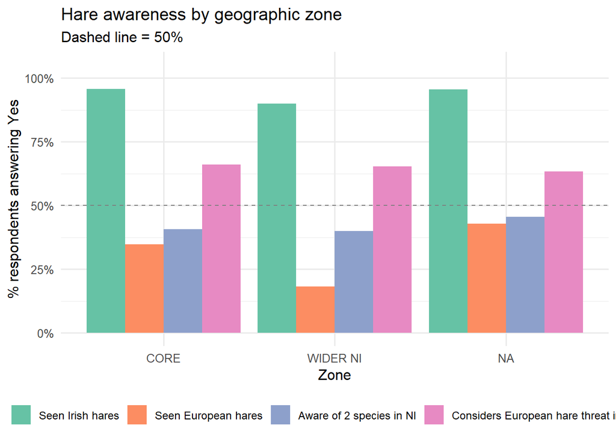

Figure 1. Proportion of respondents answering ‘Yes’ to four awareness questions, by geographic zone.

```r
aware_labels <- c(
  seen_hares                           = "Seen Irish hares",
  seen_l_europaeus                     = "Seen European hares",
  aware_of_2_sp_in_ni                  = "Aware of 2 species in NI",
  is_threat_of_l_europaeus_important   = "Considers European hare threat important"
)

hare |>
  dplyr::select(zone, all_of(aware_cols)) |>
  pivot_longer(-zone) |>
  group_by(zone, name) |>
  summarise(pct = mean(value, na.rm = TRUE) * 100, .groups = "drop") |>
  mutate(name = factor(name, levels = names(aware_labels), labels = aware_labels)) |>
  ggplot(aes(x = zone, y = pct, fill = name)) +
  geom_col(position = "dodge") +
  geom_hline(yintercept = 50, linetype = "dashed", colour = "grey50", linewidth = 0.5) +
  scale_fill_brewer(palette = "Set2") +
  scale_y_continuous(labels = percent_format(scale = 1), limits = c(0, 105)) +
  labs(title    = "Hare awareness by geographic zone",
       subtitle = "Dashed line = 50%",
       x = "Zone", y = "% respondents answering Yes", fill = NULL) +
  theme_minimal(base_size = 12) +
  theme(legend.position = "bottom",
        legend.text = element_text(size = 9))
```

## Conservation concern: a mosaic plot

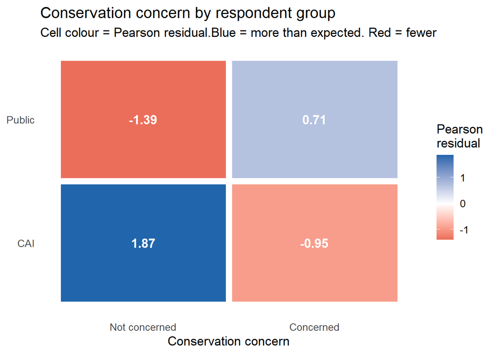

```r
# Compute residuals
tbl <- table(Group   = hare$group,
             Concern = hare$conservation_concern) |>
  (\(t) t[rowSums(t) > 0, colSums(t) > 0])()

res_df <- chisq.test(tbl)$residuals |>
  as.data.frame() |>
  rename(group = Group, concern = Concern, residual = Freq)

# Compute proportions for tile sizing
prop_df <- as.data.frame(prop.table(tbl, margin = 1)) |>
  rename(group = Group, concern = Concern, prop = Freq)

plot_df <- left_join(res_df, prop_df, by = c("group", "concern"))

ggplot(plot_df, aes(x = concern, y = group, fill = residual)) +
  geom_tile(colour = "white", linewidth = 3) +
  geom_text(aes(label = round(residual, 2)),
            size = 4.5, fontface = "bold",
            colour = "white") +
  scale_fill_gradient2(
    low      = "#d73027",
    mid      = "white",
    high     = "#2166ac",
    midpoint = 0,
    name     = "Pearson\nresidual"
  ) +
  labs(
    title    = "Conservation concern by respondent group",
    subtitle = "Cell colour = Pearson residual.Blue = more than expected. Red = fewer",
    x        = "Conservation concern",
    y        = NULL
  ) +
  theme_minimal(base_size = 13) +
  theme(panel.grid = element_blank())
```

The shading uses Pearson residuals — the difference between observed and expected cell counts, standardised by the square root of the expected count. A residual greater than ±2 is conventionally considered noteworthy. Which cells, if any, show strong deviations? What might explain them?

## Management support: bar chart and heatmap

We want to see not just overall support levels, but how much the two groups differ. A bar chart gives the absolute picture; a heatmap lets the eye quickly spot patterns across many variables simultaneously.

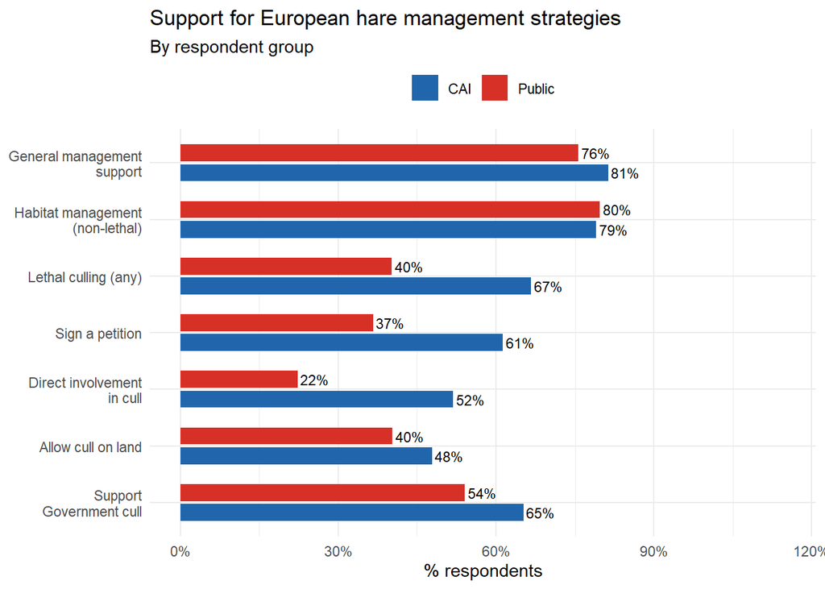

Figure 4. Support for each management strategy, by group.

```r
mgmt_labels <- c(
  support_management_of_l_europaeus       = "General management\nsupport",
  habitat_management_for_l_t_hibernicus   = "Habitat management\n(non-lethal)",
  lethal_culling                          = "Lethal culling (any)",
  support_management_via_petition         = "Sign a petition",
  support_cull_with_direct_involvement    = "Direct involvement\nin cull",
  allow_cull_on_land                      = "Allow cull on land",
  support_gov_t_cull_decision             = "Support\nGovernment cull"
)

plot_df <- hare |>
  dplyr::select(group, all_of(mgmt_cols)) |>
  pivot_longer(-group) |>
  group_by(group, name) |>
  summarise(pct = mean(value, na.rm = TRUE) * 100, .groups = "drop") |>
  mutate(name = factor(name, levels = names(mgmt_labels), labels = mgmt_labels))

p_bar <- ggplot(plot_df, aes(x = pct, y = fct_rev(name), fill = group)) +
  geom_col(position = position_dodge(0.7), width = 0.6) +
  geom_text(aes(label = paste0(round(pct), "%")),
            position = position_dodge(0.7), hjust = -0.1, size = 3) +
  scale_fill_manual(values = c("CAI" = "#2166ac", "Public" = "#d73027")) +
  scale_x_continuous(limits = c(0, 115), labels = percent_format(scale = 1)) +
  labs(title    = "Support for European hare management strategies",
       subtitle = "By respondent group",
       x = "% respondents", y = NULL, fill = NULL) +
  theme_minimal(base_size = 11) +
  theme(legend.position = "top")

print(p_bar)
```

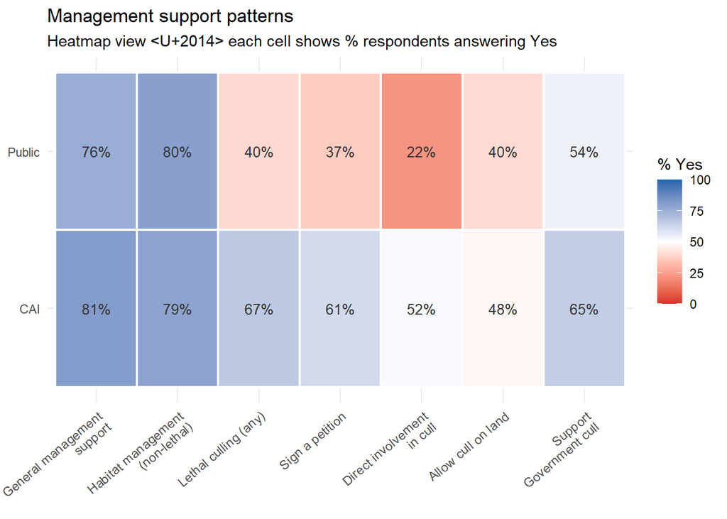

Figure 5. Heatmap of management support patterns. Blue = higher support; red = lower.

```r
ggplot(plot_df, aes(x = name, y = group, fill = pct)) +
  geom_tile(colour = "white", linewidth = 0.8) +
  geom_text(aes(label = paste0(round(pct), "%")),
            size = 3.5, colour = "grey20") +
  scale_fill_gradient2(
    low      = "#d73027",
    mid      = "white",
    high     = "#2166ac",
    midpoint = 50,
    limits   = c(0, 100),
    name     = "% Yes"
  ) +
  labs(title = "Management support patterns",
       subtitle = "Heatmap view — each cell shows % respondents answering Yes",
       x = NULL, y = NULL) +
  theme_minimal(base_size = 11) +
  theme(axis.text.x = element_text(angle = 40, hjust = 1, size = 9))
```

The bar chart is better for reading exact values and comparing groups side-by-side. The heatmap is better for spotting patterns across many variables at once. Neither is objectively superior — it depends on what question you are trying to answer. In a real report, you would probably use one or the other, not both.

# Group comparisons: Chi-square and Fisher’s exact tests

## Theory

The chi-square test ($\chi^2$) asks a simple question: is there a statistically significant association between two categorical variables? It does so by comparing the counts of actual observations to the counts you would expect if the variables were completely independent.

When any expected cell count falls below 5, the $\chi^2$ approximation becomes unreliable. Fisher’s exact test calculates the exact probability rather than an approximation so is always valid.

A chi-square test does not tell Whether the association is large or small, however. A statistically significant result only means that the effect is probably not zero and not that it is meaningful. To explore meaning we need a measure of effect size.

## Cramér’s V: measuring effect size

Cramér’s $V$ scales the $\chi^2$ statistic to a 0–1 range, correcting for sample size and table dimensions. Typically we interpret $V$ as $\approx 0.1$ = small, $V \approx 0.3$ = medium, $V \approx 0.5$ = large.

## Applying to our data

```r
# A function that runs the appropriate test for a single variable
compare_groups <- function(var, data = hare) {
  tbl    <- table(data$group, data[[var]])
  # Suppress warnings about small expected values (we check manually)
  exp_ct <- suppressWarnings(chisq.test(tbl)$expected)

  if (any(exp_ct < 5, na.rm = TRUE)) {
    test   <- fisher.test(tbl)
    method <- "Fisher"
    stat   <- NA_real_
    p      <- test$p.value
    OR     <- as.numeric(test$estimate)
  } else {
    test   <- suppressWarnings(chisq.test(tbl))
    method <- "Chi-sq"
    stat   <- as.numeric(test$statistic)
    p      <- test$p.value
    # Cramér's V for chi-square
    n_obs  <- sum(tbl)
    OR     <- sqrt(stat / (n_obs * (min(dim(tbl)) - 1)))  # repurpose column for V
  }

  tibble(
    variable  = var,
    method    = method,
    statistic = round(stat, 3),
    p_value   = round(p, 4),
    cramers_V_or_OR = round(OR, 3),
    effect_note = if_else(method == "Chi-sq", "Cramer's V", "Odds ratio"),
    sig = case_when(p < 0.001 ~ "***",
                    p < 0.01  ~ "**",
                    p < 0.05  ~ "*",
                    TRUE       ~ "")
  )
}
```

```r
comparison_table <- map_dfr(mgmt_cols, compare_groups) |>
  arrange(p_value) |>
  mutate(
    p_bonferroni = p.adjust(p_value, method = "bonferroni"),
    sig_bonf     = case_when(p_bonferroni < 0.001 ~ "***",
                              p_bonferroni < 0.01  ~ "**",
                              p_bonferroni < 0.05  ~ "*",
                              TRUE                  ~ "ns")
  )

comparison_table |>
  dplyr::select(variable, method, statistic, p_value, cramers_V_or_OR,
         effect_note, sig, sig_bonf) |>
  knitr::kable(
    caption = "Table 2. Statistical comparisons of management support between CAI members and Public respondents. Sig. = before Bonferroni correction; Sig. (Bonf.) = after correction.",
    col.names = c("Variable","Test","Statistic","p-value",
                  "Effect size","Measure","Sig.","Sig. (Bonf.)")
  )
```

Table 2. Statistical comparisons of management support between CAI members and Public respondents. Sig. = before Bonferroni correction; Sig. (Bonf.) = after correction.

| Variable | Test | Statistic | p-value | Effect size | Measure | Sig. | Sig. (Bonf.) |
| --- | --- | --- | --- | --- | --- | --- | --- |
| lethal_culling | Chi-sq | 21.041 | 0.0000 | 0.256 | Cramer’s V | *** | *** |
| support_management_via_petition | Chi-sq | 18.508 | 0.0000 | 0.238 | Cramer’s V | *** | *** |
| support_cull_with_direct_involvement | Chi-sq | 28.094 | 0.0000 | 0.300 | Cramer’s V | *** | *** |
| support_gov_t_cull_decision | Chi-sq | 3.571 | 0.0588 | 0.105 | Cramer’s V |  | ns |
| support_management_of_l_europaeus | Chi-sq | 1.191 | 0.2751 | 0.060 | Cramer’s V |  | ns |
| allow_cull_on_land | Chi-sq | 0.752 | 0.3857 | 0.062 | Cramer’s V |  | ns |
| habitat_management_for_l_t_hibernicus | Chi-sq | 0.000 | 1.0000 | 0.000 | Cramer’s V |  | ns |

## Does species awareness predict management support?

An ecologically interesting sub-question: do respondents who know there are two hare species in Northern Ireland show different levels of support for management?

```r
hare |>
  filter(!is.na(aware_of_2_sp_in_ni),
         !is.na(support_management_of_l_europaeus)) |>
  count(aware_of_2_sp_in_ni, support_management_of_l_europaeus) |>
  mutate(
    aware_of_2_sp_in_ni              = if_else(aware_of_2_sp_in_ni, "Aware", "Not aware"),
    support_management_of_l_europaeus = if_else(support_management_of_l_europaeus,
                                                 "Supports", "Opposes")
  ) |>
  knitr::kable(caption = "Table 3. Species awareness vs management support crosstab.")
```

Table 3. Species awareness vs management support crosstab.

| aware_of_2_sp_in_ni | support_management_of_l_europaeus | n |
| --- | --- | --- |
| Not aware | Opposes | 39 |
| Not aware | Supports | 151 |
| Aware | Opposes | 33 |
| Aware | Supports | 108 |

```r
fisher.test(table(hare$aware_of_2_sp_in_ni,
                  hare$support_management_of_l_europaeus))
```

```
##
##  Fisher's Exact Test for Count Data
##
## data:  table(hare$aware_of_2_sp_in_ni, hare$support_management_of_l_europaeus)
## p-value = 0.5904
## alternative hypothesis: true odds ratio is not equal to 1
## 95 percent confidence interval:
##  0.4839208 1.4835166
## sample estimates:
## odds ratio
##  0.8457105
```

If people who are *more* aware of the species distinction are *less* likely to support management, what might this suggest? Could ecological knowledge cut both ways - increasing concern for the Irish hare but also increasing reluctance to sanction lethal control of the other? This is a genuinely interesting question that has real implications for how conservation communication should be framed.

# Response linkage: association analysis

## Theory: phi coefficients for binary data

So far we have been looking at one variable at a time, or comparing one variable against group membership. But survey responses are not independent of each other. Someone who says they would sign a petition may also be likely to allow a cull on their land. Mapping these internal associations reveals the structure of opinion.

For two binary (Y/N) variables, the appropriate correlation coefficient is **phi** ($\phi$), which is conceptually identical to Pearson’s $r$ applied to 0/1-coded data.

## Computing the phi matrix

```r
all_binary_cols <- c(aware_cols, mgmt_cols, "member_of_conservation_org", activity_cols)

binary_mat <- hare |>
  dplyr::select(all_of(all_binary_cols)) |>
  mutate(across(everything(), as.integer))

phi_mat <- cor(binary_mat, use = "pairwise.complete.obs")
phi_mat[is.na(phi_mat)] <- 0  # replace NA correlations with 0

# Readable labels
nice_names <- c(
  seen_hares                           = "Seen Irish hare",
  seen_l_europaeus                     = "Seen Eur. hare",
  aware_of_2_sp_in_ni                  = "Aware 2 spp",
  is_threat_of_l_europaeus_important   = "Threat important",
  support_management_of_l_europaeus    = "Support mgmt",
  habitat_management_for_l_t_hibernicus= "Habitat mgmt",
  lethal_culling                       = "Lethal cull",
  support_management_via_petition      = "Petition",
  support_cull_with_direct_involvement = "Direct involve",
  allow_cull_on_land                   = "Allow cull",
  support_gov_t_cull_decision          = "Govt cull",
  member_of_conservation_org           = "Consv org",
  hunt                                 = "Hunt",
  game_birds                           = "Game birds",
  rabbits                              = "Rabbits",
  wildfowl                             = "Wildfowl",
  fishing_angling                      = "Fishing"
)
rownames(phi_mat) <- colnames(phi_mat) <- nice_names[colnames(phi_mat)]
```

## Heatmap of phi coefficients

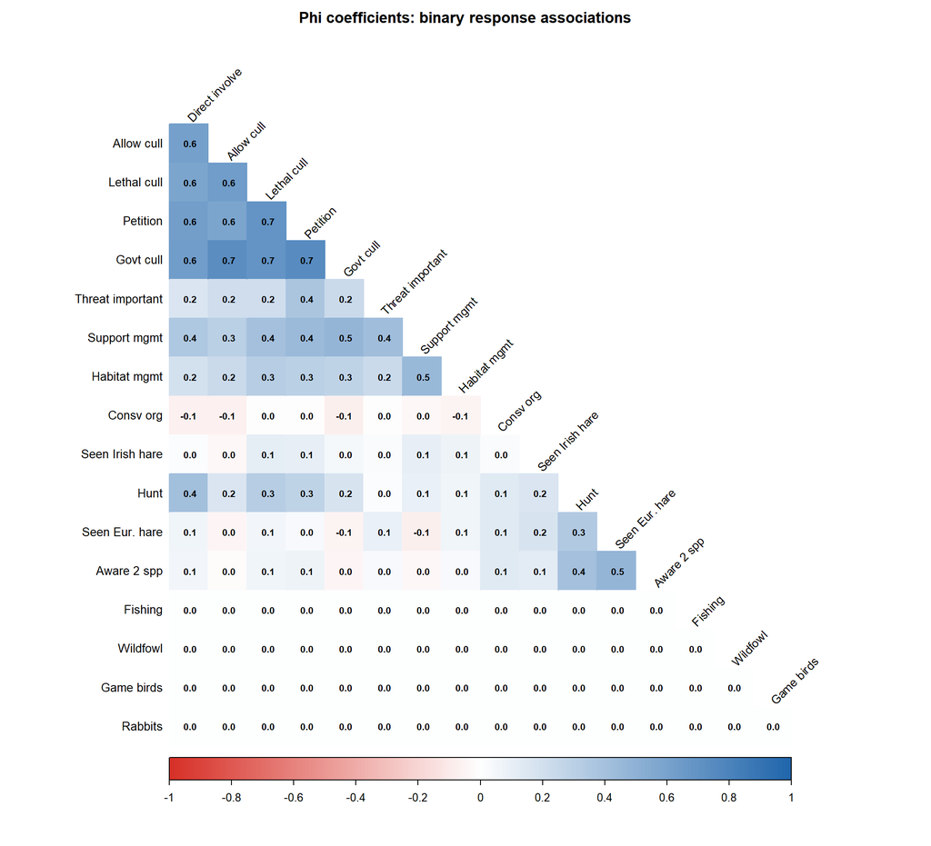

Figure 6. Pairwise phi (φ) coefficients between all binary response variables. Blue = positive association; red = negative association.

```r
# Make the plot device tall and wide before calling corrplot
par(oma = c(0, 0, 2, 0))  # outer margin for title

corrplot(
  phi_mat,
  method       = "color",
  type         = "lower",          # full matrix reads better at this size
  order        = "hclust",        # group correlated variables together
  hclust.method = "ward.D2",      # matches your clustering analysis
  tl.cex       = 0.85,            # larger labels
  tl.col       = "black",
  tl.srt       = 45,              # angled top labels, less cramped
  addCoef.col  = "black",
  number.cex   = 0.65,
  number.digits = 1,              # 1 decimal place keeps cells readable
  col          = colorRampPalette(c("#d73027", "white", "#2166ac"))(200),
  mar          = c(0, 0, 1, 0),
  diag         = FALSE            # hide the diagonal 1s
)
title("Phi coefficients: binary response associations",
      outer = TRUE, cex.main = 1.1)
```

## Hierarchical clustering: what clusters with what?

Hierarchical clustering groups variables by similarity. Here we treat $1 - |\phi|$ as a distance (so highly associated variables, whether positively or negatively, are close together), and use Ward’s D2 linkage to merge groups.

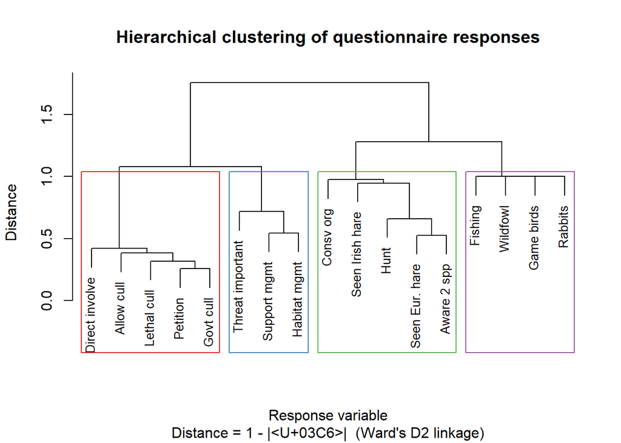

Figure 7. Hierarchical clustering of response variables (Ward’s D2). Coloured rectangles suggest four natural clusters.

```r
dist_mat   <- as.dist(1 - abs(phi_mat))
hclust_res <- hclust(dist_mat, method = "ward.D2")

plot(hclust_res,
     main  = "Hierarchical clustering of questionnaire responses",
     sub   = "Distance = 1 - |φ|  (Ward's D2 linkage)",
     xlab  = "Response variable",
     ylab  = "Distance",
     cex   = 0.85)
rect.hclust(hclust_res, k = 4,
            border = c("#e41a1c", "#377eb8", "#4daf4a", "#984ea3"))
```

Variables that merge at a low height are closely associated. Variables that only merge near the top of the tree are weakly associated. The coloured rectangles suggest a four-cluster partition but selecting $k$ is a judgement call, not an algorithm output. Try `k = 3` and `k = 5` and see how the interpretation changes.

## Association network

We can go one step further and visualise the associations as a network where variables are nodes, and we draw an edge between two nodes if their $|\phi| > 0.3$ (a conventional threshold for a “meaningful” binary association). Edge thickness and colour encode the strength and direction of the association.

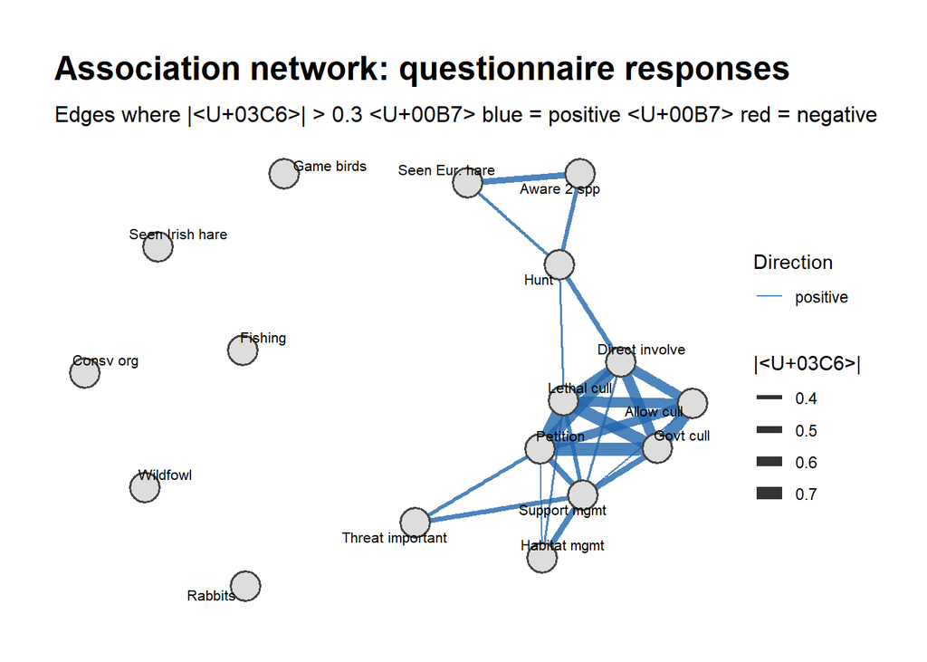

Figure 8. Association network of questionnaire responses. Edges shown where |φ| > 0.3. Blue = positive association; red = negative.

```r
phi_long <- as_tibble(phi_mat, rownames = "from") |>
  pivot_longer(-from, names_to = "to", values_to = "phi") |>
  filter(from < to,        # lower triangle only — avoid duplicate edges
         abs(phi) > 0.3,
         !is.na(phi))

if (nrow(phi_long) > 0) {
  g <- graph_from_data_frame(
    d        = phi_long |> mutate(weight = abs(phi)),
    directed = FALSE,
    vertices = tibble(name = colnames(phi_mat))
  )
  E(g)$sign <- ifelse(phi_long$phi > 0, "positive", "negative")

  set.seed(42)
  ggraph(g, layout = "fr") +
    geom_edge_link(aes(width = weight, colour = sign), alpha = 0.8) +
    geom_node_point(size = 7, colour = "#444444", fill = "#dddddd",
                    shape = 21, stroke = 1) +
    geom_node_text(aes(label = name), size = 2.8, repel = TRUE,
                   max.overlaps = 20) +
    scale_edge_width(range = c(0.5, 3.5), name = "|φ|") +
    scale_edge_colour_manual(
      values = c(positive = "#2166ac", negative = "#d73027"),
      name   = "Direction"
    ) +
    labs(
      title    = "Association network: questionnaire responses",
      subtitle = "Edges where |φ| > 0.3 · blue = positive · red = negative"
    ) +
    theme_graph(base_family = "sans") +
    theme(legend.position = "right")
} else {
  cat("No pairs with |phi| > 0.3 in this sample. Try lowering the threshold.\n")
}
```

In a well-designed attitude survey, you often see two major clusters: one for knowledge/awareness items and one for action/support items. Do these emerge here? What does it mean if awareness and support cluster together — or separately?

# Logistic Regression: Predicting Support for a Government Cull

We have established *that* the groups differ. Now we want to know what predicts support for the most politically significant outcome: a government-planned cull (Q20). Our outcome is binary — it can only be 0 or 1. Ordinary linear regression can predict values outside this range, which is nonsensical. Logistic regression models the *log-odds* of the outcome, guaranteeing that predicted probabilities stay between 0 and 1.

## Fitting the model

```r
hare_mod <- hare |>
  mutate(
    group                = relevel(group, ref = "Public"),
    conservation_concern = relevel(conservation_concern, ref = "Not concerned")
  ) |>
  filter(!is.na(support_gov_t_cull_decision))

glm_fit <- glm(
  support_gov_t_cull_decision ~
    group + zone + own_rent_land + conservation_concern +
    aware_of_2_sp_in_ni + consider_hares_pests +
    is_threat_of_l_europaeus_important + hunt,
  data   = hare_mod,
  family = binomial(link = "logit")
)

summary(glm_fit)
```

```
##
## Call:
## glm(formula = support_gov_t_cull_decision ~ group + zone + own_rent_land +
##     conservation_concern + aware_of_2_sp_in_ni + consider_hares_pests +
##     is_threat_of_l_europaeus_important + hunt, family = binomial(link = "logit"),
##     data = hare_mod)
##
## Coefficients:
##                                        Estimate Std. Error z value Pr(>|z|)
## (Intercept)                            -0.27934    0.63674  -0.439  0.66087
## groupCAI                                0.33672    0.54989   0.612  0.54032
## zoneWIDER NI                            0.12025    0.39293   0.306  0.75958
## own_rent_landTRUE                      -0.18823    0.43808  -0.430  0.66743
## conservation_concernConcerned           0.03916    0.49175   0.080  0.93653
## aware_of_2_sp_in_niTRUE                -1.03968    0.47738  -2.178  0.02941 *
## consider_hares_pestsTRUE               -0.42338    0.49247  -0.860  0.38995
## is_threat_of_l_europaeus_importantTRUE  1.11992    0.40711   2.751  0.00594 **
## huntTRUE                                1.24511    0.57444   2.168  0.03019 *
## ---
## Signif. codes:  0 '***' 0.001 '**' 0.01 '*' 0.05 '.' 0.1 ' ' 1
##
## (Dispersion parameter for binomial family taken to be 1)
##
##     Null deviance: 180.88  on 136  degrees of freedom
## Residual deviance: 159.53  on 128  degrees of freedom
##   (184 observations deleted due to missingness)
## AIC: 177.53
##
## Number of Fisher Scoring iterations: 4
```

## Odds ratios and confidence intervals

We calculate odds ratios in logistic regression to express how much the odds of an outcome change when a predictor increases or differs between groups. They make results easier to interpret by turning model coefficients into a clear “how many times more or less likely” comparison.

```r
glm_tidy <- tidy(glm_fit, conf.int = TRUE, exponentiate = TRUE) |>
  filter(term != "(Intercept)") |>
  mutate(
    sig = case_when(p.value < 0.001 ~ "***",
                    p.value < 0.01  ~ "**",
                    p.value < 0.05  ~ "*",
                    TRUE             ~ "")
  )

glm_tidy |>
  dplyr::select(term, estimate, conf.low, conf.high, p.value, sig) |>
  knitr::kable(
    digits  = 3,
    caption = "Table 4. Logistic regression results. Odds ratios (ORs) with 95% confidence intervals and p-values. Reference group: Public respondents; Not concerned about conservation.",
    col.names = c("Predictor", "OR", "95% CI lower", "95% CI upper", "p-value", "Sig.")
  )
```

Table 4. Logistic regression results. Odds ratios (ORs) with 95% confidence intervals and p-values. Reference group: Public respondents; Not concerned about conservation.

| Predictor | OR | 95% CI lower | 95% CI upper | p-value | Sig. |
| --- | --- | --- | --- | --- | --- |
| groupCAI | 1.400 | 0.472 | 4.164 | 0.540 |  |
| zoneWIDER NI | 1.128 | 0.523 | 2.459 | 0.760 |  |
| own_rent_landTRUE | 0.828 | 0.347 | 1.956 | 0.667 |  |
| conservation_concernConcerned | 1.040 | 0.388 | 2.705 | 0.937 |  |
| aware_of_2_sp_in_niTRUE | 0.354 | 0.133 | 0.877 | 0.029 | * |
| consider_hares_pestsTRUE | 0.655 | 0.247 | 1.732 | 0.390 |  |
| is_threat_of_l_europaeus_importantTRUE | 3.065 | 1.397 | 6.945 | 0.006 | ** |
| huntTRUE | 3.473 | 1.169 | 11.354 | 0.030 | * |

```
## `height` was translated to `width`.
```

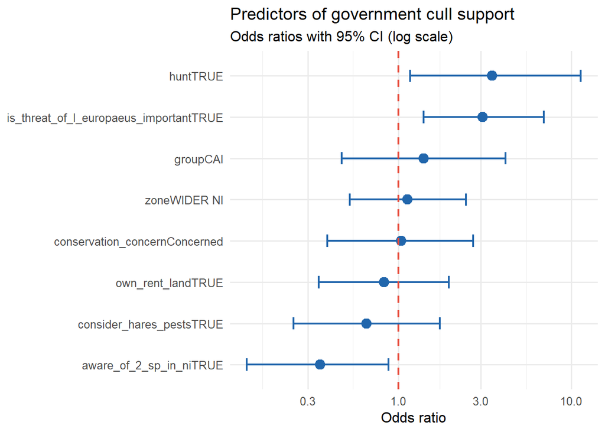

Figure 9. Coefficient plot from logistic regression. Points are odds ratios; bars are 95% confidence intervals. Red dashed line = OR of 1.0 (no effect). X-axis is log-scaled.

```r
ggplot(glm_tidy, aes(x = estimate, y = reorder(term, estimate))) +
  geom_point(size = 3.5, colour = "#2166ac") +
  geom_errorbarh(aes(xmin = conf.low, xmax = conf.high),
                 height = 0.3, colour = "#2166ac", linewidth = 0.8) +
  geom_vline(xintercept = 1, linetype = "dashed", colour = "#e74c3c",
             linewidth = 0.8) +
  scale_x_log10() +
  labs(
    title    = "Predictors of government cull support",
    subtitle = "Odds ratios with 95% CI (log scale)",
    x = "Odds ratio", y = NULL
  ) +
  theme_minimal(base_size = 12)
```

## Model fit

```r
cat("AIC:", round(AIC(glm_fit), 1), "\n")
```

```
## AIC: 177.5
```

```r
cat("Null deviance:", round(glm_fit$null.deviance, 1),
    "on", glm_fit$df.null, "df\n")
```

```
## Null deviance: 180.9 on 136 df
```

```r
cat("Residual deviance:", round(glm_fit$deviance, 1),
    "on", glm_fit$df.residual, "df\n")
```

```
## Residual deviance: 159.5 on 128 df
```

```r
cat("McFadden pseudo-R:",
    round(1 - glm_fit$deviance / glm_fit$null.deviance, 3), "\n")
```

```
## McFadden pseudo-R: 0.118
```

Unlike the usual $R^2$ in linear regression, McFadden’s pseudo-$R^2$ does not tell you how much of the outcome is “explained” by the model. Instead, it tells you how much better your model fits the data compared to a baseline model with only an intercept. Values around 0.2–0.4 are often considered quite good in social science, but it should be interpreted cautiously rather than taken as a strict measure of model quality.

Which predictors have ORs substantially different from 1.0? Are the confidence intervals narrow (precise estimates) or wide (high uncertainty)? How might you improve the model? What would an interaction between `group` and `aware_of_2_sp_in_ni` mean conceptually?

# Thematic analysis of multi-select responses

## Theory

Some questions in the survey were multi-select, i.e., respondents could tick all that applied. These cannot be treated as simple binary variables as the combination of choices carries meaning.

## Culling method profiles

```r
cull_mat <- hare |>
  dplyr::select(group, all_of(cull_methods)) |>
  filter(!is.na(shooting) | !is.na(netting) | !is.na(trapping)) |>
  mutate(across(all_of(cull_methods), ~replace_na(as.integer(.), 0L))) |>
  mutate(
    n_methods = shooting + netting + trapping,
    profile   = case_when(
      n_methods == 0              ~ "None selected",
      shooting & !netting & !trapping ~ "Shooting only",
      !shooting & netting & !trapping ~ "Netting only",
      !shooting & !netting & trapping ~ "Trapping only",
      shooting & netting & !trapping  ~ "Shooting + Netting",
      shooting & !netting & trapping  ~ "Shooting + Trapping",
      !shooting & netting & trapping  ~ "Netting + Trapping",
      TRUE                            ~ "All three"
    )
  )

count(cull_mat, group, profile) |> arrange(group, desc(n))
```

```
##     group             profile  n
## 1     CAI       Shooting only 34
## 2     CAI           All three 29
## 3     CAI        Netting only 21
## 4     CAI  Shooting + Netting  7
## 5     CAI  Netting + Trapping  5
## 6     CAI       Trapping only  4
## 7     CAI Shooting + Trapping  2
## 8  Public       Shooting only 33
## 9  Public        Netting only 27
## 10 Public           All three 13
## 11 Public  Netting + Trapping 10
## 12 Public       Trapping only  9
## 13 Public  Shooting + Netting  2
```

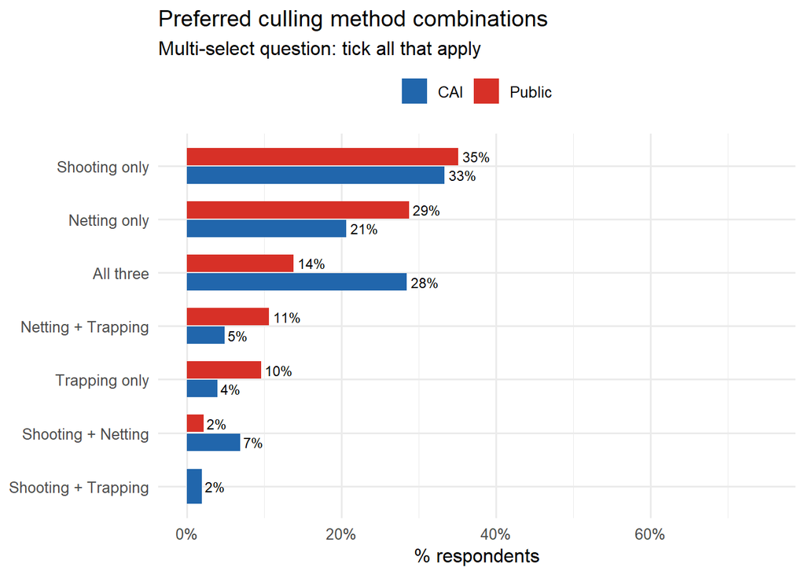

Figure 10. Preferred culling method combinations by respondent group.

```r
cull_mat |>
  count(group, profile) |>
  group_by(group) |>
  mutate(pct = n / sum(n) * 100) |>
  ggplot(aes(x = pct, y = reorder(profile, pct), fill = group)) +
  geom_col(position = position_dodge(0.7), width = 0.65) +
  geom_text(aes(label = paste0(round(pct), "%")),
            position = position_dodge(0.7), hjust = -0.15, size = 3) +
  scale_fill_manual(values = c("CAI" = "#2166ac", "Public" = "#d73027")) +
  scale_x_continuous(limits = c(0, 75), labels = percent_format(scale = 1)) +
  labs(title    = "Preferred culling method combinations",
       subtitle = "Multi-select question: tick all that apply",
       x = "% respondents", y = NULL, fill = NULL) +
  theme_minimal(base_size = 12) +
  theme(legend.position = "top")
```

## Linking themes to attitudes

We can use chi-square to quantitatively test whether culling method preference differs between groups.

```r
profile_tbl <- table(cull_mat$group, cull_mat$profile)
chisq.test(profile_tbl)
```

```
##
##  Pearson's Chi-squared test
##
## data:  profile_tbl
## X-squared = 14.926, df = 6, p-value = 0.02084
```

## Activity co-occurrence: the Jaccard index

For the rural activities question, we want to know which activities tend to co-occur, i.e., which activities are commonly practised together. We use the Jaccard similarity index, which measures the overlap between two sets. A Jaccard of 1 means the two activities always occur together; 0 means they never do.

```r
act_mat <- hare |>
  dplyr::select(all_of(activity_cols)) |>
  mutate(across(everything(), ~replace_na(as.integer(.), 0L))) |>
  as.matrix()

co_occur <- t(act_mat) %*% act_mat   # n(i AND j) for all pairs
diag(co_occur) <- 0

n_each      <- colSums(act_mat)
jaccard_mat <- matrix(NA_real_, nrow = ncol(act_mat), ncol = ncol(act_mat),
                      dimnames = list(activity_cols, activity_cols))

for (i in seq_len(ncol(act_mat))) {
  for (j in seq_len(ncol(act_mat))) {
    union_ij          <- n_each[i] + n_each[j] - co_occur[i, j]
    jaccard_mat[i, j] <- if (union_ij > 0) co_occur[i, j] / union_ij else 0
  }
}

round(jaccard_mat, 2)
```

```
##                 hunt game_birds rabbits wildfowl fishing_angling
## hunt            0.00       0.66    0.54     0.54            0.44
## game_birds      0.66       0.00    0.56     0.71            0.53
## rabbits         0.54       0.56    0.00     0.54            0.38
## wildfowl        0.54       0.71    0.54     0.00            0.53
## fishing_angling 0.44       0.53    0.38     0.53            0.00
```

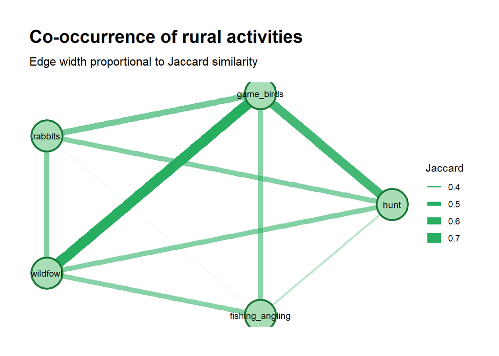

Figure 11. Co-occurrence network of rural activities. Edge width = Jaccard similarity index.

```r
g_act <- graph_from_adjacency_matrix(
  jaccard_mat, mode = "undirected", weighted = TRUE, diag = FALSE
)

set.seed(7)
ggraph(g_act, layout = "circle") +
  geom_edge_link(aes(width = weight, alpha = weight), colour = "#27ae60") +
  geom_node_point(size = 14, colour = "#1a7837", fill = "#a8ddb5",
                  shape = 21, stroke = 1.5) +
  geom_node_text(aes(label = name), size = 3.2, colour = "black") +
  scale_edge_width(range = c(0.3, 5), name = "Jaccard") +
  scale_edge_alpha(range = c(0.2, 1), guide = "none") +
  labs(title    = "Co-occurrence of rural activities",
       subtitle = "Edge width proportional to Jaccard similarity") +
  theme_graph(base_family = "sans")
```

## Respondent typology

Finally, we create a simple classification by combining two measures: awareness (how much a respondent knows) and support (how strongly they support active management). This is similar to stakeholder mapping, where people are grouped based on their knowledge and attitudes to help guide conservation decisions.

```r
hare <- hare |>
  mutate(
    awareness_index = as.integer(seen_hares) +
                      as.integer(aware_of_2_sp_in_ni) +
                      as.integer(is_threat_of_l_europaeus_important),

    support_index   = as.integer(support_management_of_l_europaeus) +
                      as.integer(lethal_culling) +
                      as.integer(support_management_via_petition) +
                      as.integer(support_cull_with_direct_involvement) +
                      as.integer(allow_cull_on_land) +
                      as.integer(support_gov_t_cull_decision),

    activity_breadth = as.integer(hunt) + as.integer(game_birds) +
                       as.integer(rabbits) + as.integer(wildfowl) +
                       as.integer(fishing_angling),

    typology = case_when(
      support_index >= 4 & awareness_index >= 2 ~ "Informed advocate",
      support_index >= 4 & awareness_index <  2 ~ "Pragmatic advocate",
      support_index <  2 & awareness_index >= 2 ~ "Aware but opposed",
      support_index <  1 & awareness_index <  1 ~ "Disengaged",
      TRUE                                      ~ "Ambivalent"
    ),
    typology = factor(typology,
                      levels = c("Informed advocate", "Pragmatic advocate",
                                 "Ambivalent", "Aware but opposed", "Disengaged"))
  )

count(hare, group, typology) |> arrange(group, typology)
```

```
##    group           typology   n
## 1    CAI  Informed advocate  27
## 2    CAI Pragmatic advocate   6
## 3    CAI         Ambivalent  83
## 4    CAI  Aware but opposed  23
## 5 Public  Informed advocate  32
## 6 Public Pragmatic advocate   8
## 7 Public         Ambivalent 130
## 8 Public  Aware but opposed  31
## 9 Public         Disengaged   1
```

It’s important to note that the thresholds used to define these categories are based on subjective judgement rather than fixed rules. This means that different reasonable cut-offs could change how individuals are grouped, so the typology should be interpreted as a useful simplification rather than a precise classification. Where possible, these thresholds should be checked against empirical evidence or validated with expert judgement to ensure they are meaningful and robust.

[figure not shown]

Figure 12. Respondent typology by group, derived from awareness and management support indices.

```r
hare |>
  filter(!is.na(typology)) |>
  count(group, typology) |>
  group_by(group) |>
  mutate(pct = n / sum(n) * 100) |>
  ggplot(aes(x = pct, y = fct_rev(typology), fill = group)) +
  geom_col(position = position_dodge(0.7), width = 0.65) +
  geom_text(aes(label = paste0(round(pct), "%")),
            position = position_dodge(0.7), hjust = -0.1, size = 3.2) +
  scale_fill_manual(values = c("CAI" = "#2166ac", "Public" = "#d73027")) +
  scale_x_continuous(limits = c(0, 75), labels = percent_format(scale = 1)) +
  labs(
    title    = "Respondent typology by group",
    subtitle = "Based on awareness index (0–4) and support index (0–6)",
    x = "% respondents", y = NULL, fill = NULL
  ) +
  theme_minimal(base_size = 12) +
  theme(legend.position = "top")
```

How would you use these typologies in conservation practice? The “informed advocate” already knows and supports so do you need to spend resources on them? The “pragmatic advocate” supports but doesn’t really know why; are they a potential liability if the evidence changes? The “aware but opposed” understand the issue and still say no. What would it take to change their mind, and should you try?

# Latent Class Analysis (LCA)

Imagine you have given 341 people a survey with 11 yes/no questions. You now have 341 rows of 1s and 0s. LCA asks whether, beneath all the variation, are there a small number of distinct types of respondent and if so, how many, and what defines each type?

A latent variable is one you cannot observe directly, one that is hidden in the data. In this case, the latent variable is respondent type - the underlying attitude profile that caused a particular person to answer the way they did. LCA tries to recover that hidden structure from the pattern of observed responses.

Previously we created a typology by applying rules designed by us. That is perfectly reasonable, but the thresholds and dimensions are our choices. LCA makes no such assumptions. Instead, it finds the grouping that best explains the observed pattern of responses statistically without requiring us to decide in advance what the groups should look like or how many there should be. The two approaches should broadly agree if your hand-coded typology is capturing something real but where they diverge is informative.

LCA assumes that each respondent belongs to one of K unobserved classes. Within each class, responses to individual questions are assumed to be independent of each other (local independence assumption). This might run counter to your own understanding of the data. You might expect, for example, “supports lethal culling” and “supports a government cull” to be correlated. But LCA suggests that they are only correlated because they are both influenced by the same underlying class membership. Once you know which class someone belongs to, knowing their answer to one question tells you nothing extra about their answer to another. The class explains the correlation.

The model estimates: - Class proportions. I.e., what fraction of the population belongs to each class. If K = 3, you might get classes of 45%, 35%, and 20%. - Item response probabilities. I.e., for each class and each question, the probability that a member of that class answers “Yes”. A class with P(lethal culling = Yes) = 0.92 is very different from one with P(lethal culling = Yes) = 0.18.

```r
# poLCA requires indicators coded as positive integers starting at 1.
# Our binary columns are TRUE/FALSE — add 1L to make them 1/2.

lca_vars <- c(
  "seen_l_europaeus", "aware_of_2_sp_in_ni",
  "is_threat_of_l_europaeus_important", "consider_hares_pests",
  "support_management_of_l_europaeus", "habitat_management_for_l_t_hibernicus",
  "lethal_culling", "support_management_via_petition",
  "support_cull_with_direct_involvement", "allow_cull_on_land",
  "support_gov_t_cull_decision"
)

lca_df <- hare |>
  dplyr::select(all_of(lca_vars)) |>
  mutate(across(everything(), ~ as.integer(.) + 1L)) |>  # FALSE→1, TRUE→2
  drop_na()

# poLCA needs a formula listing all indicators
lca_formula <- as.formula(
  paste("cbind(", paste(lca_vars, collapse = ","), ") ~ 1")
)

# Choose the number of classes
# Fit models with 2–5 classes and compare AIC / BIC.
# BIC tends to favour more parsimonious solutions; AIC can overfit slightly.

fit_lca <- function(k) {
  poLCA(lca_formula, data = lca_df, nclass = k,
        maxiter = 3000, tol = 1e-6,
        verbose = FALSE, nrep = 10)   # nrep: 10 random starts, keeps best
}

set.seed(42)
models <- map(2:5, fit_lca)

# Model fit table
fit_table <- tibble(
  K      = 2:5,
  logLik = map_dbl(models, ~ .x$llik),
  AIC    = map_dbl(models, ~ .x$aic),
  BIC    = map_dbl(models, ~ .x$bic),
  df     = map_int(models, ~ .x$resid.df)
)
print(fit_table)
```

```
## # A tibble: 4 x 5
##       K logLik   AIC   BIC    df
##   <int>  <dbl> <dbl> <dbl> <int>
## 1     2  -839. 1724. 1794.   127
## 2     3  -812. 1694. 1800.   115
## 3     4  -789. 1672. 1813.   103
## 4     5  -772. 1662. 1840.    91
```

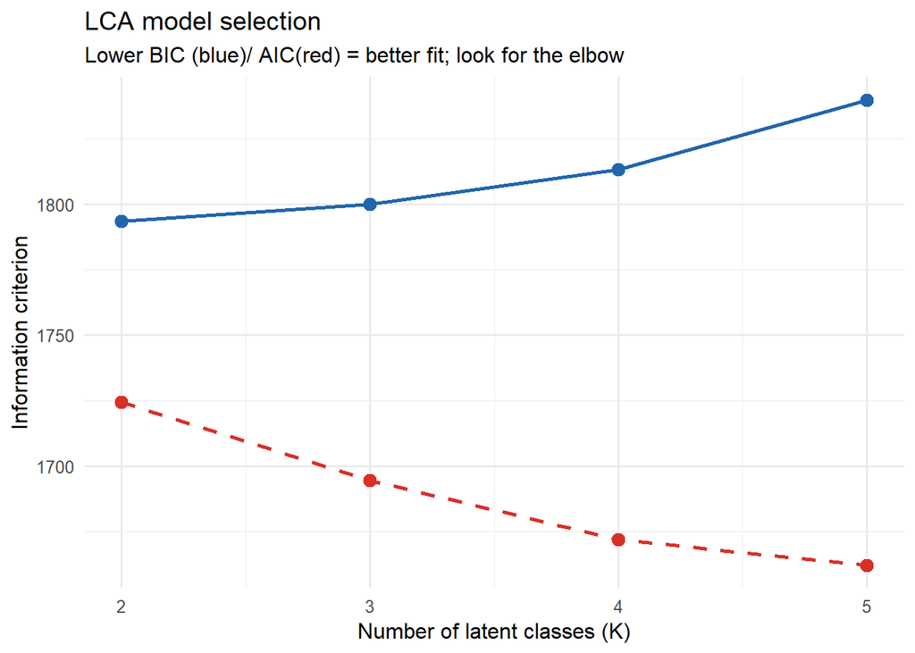

```r
# Scree-style plot of BIC
ggplot(fit_table, aes(x = K, y = BIC)) +
  geom_line(linewidth = 1, colour = "#2166ac") +
  geom_point(size = 3,   colour = "#2166ac") +
  geom_line(aes(y = AIC), linewidth = 1, colour = "#d73027", linetype = "dashed") +
  geom_point(aes(y = AIC), size = 3, colour = "#d73027") +
  labs(title    = "LCA model selection",
       subtitle = "Lower BIC (blue)/ AIC(red) = better fit; look for the elbow",
       x = "Number of latent classes (K)", y = "Information criterion") +
  theme_minimal(base_size = 12)
```

```r
# Select and label the best model
best_model <- models[[2]]   # models[[1]] = K=2, models[[2]] = K=3, etc.
K <- length(unique(best_model$predclass))
cat("Using K =", K, "classes\n")
```

```
## Using K = 3 classes
```

For this example we manually select K = 3 to illustrate interpretation. In practice, K should be chosen empirically based on the BIC/AIC and the point at which adding another class produces diminishing returns in fit.

To use the empirically best model instead, replace the line above with:

```r
best_model <- models[[which.min(map_dbl(models, ~ .x$bic)) ]]
K <- length(unique(best_model$predclass))
cat("Best K by BIC:", K, "\n")
```

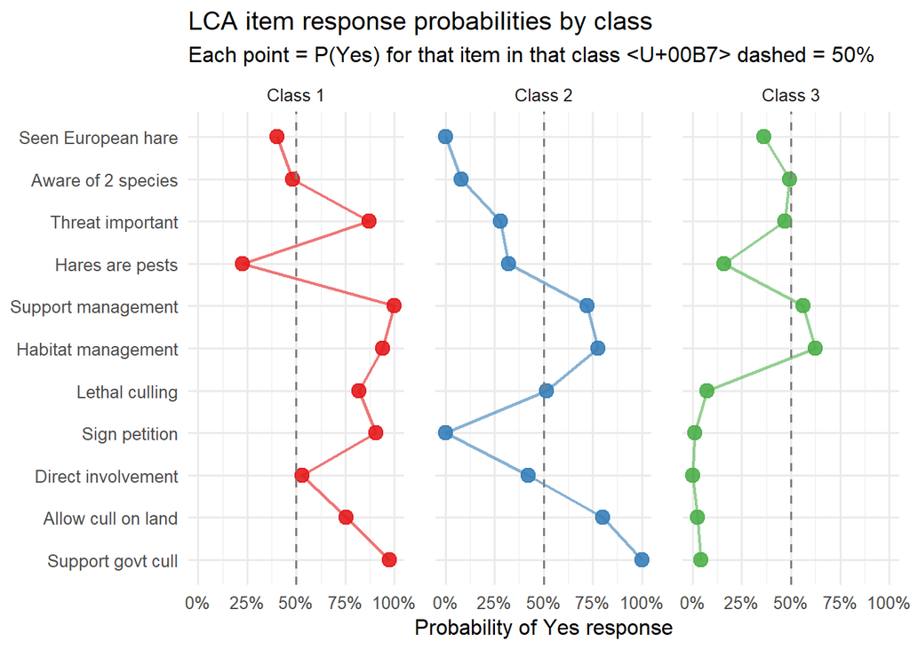

```r
# Extract item response probabilities
# probs[[item]][class, response] — we want response = 2 (TRUE)
probs_df <- imap_dfr(best_model$probs, function(mat, item) {
  tibble(
    item  = item,
    class = paste0("Class ", seq_len(nrow(mat))),
    prob  = mat[, 2]          # probability of YES (response = 2)
  )
})

# Readable item labels
item_labels <- c(
  seen_l_europaeus                      = "Seen European hare",
  aware_of_2_sp_in_ni                   = "Aware of 2 species",
  is_threat_of_l_europaeus_important    = "Threat important",
  consider_hares_pests                  = "Hares are pests",
  support_management_of_l_europaeus     = "Support management",
  habitat_management_for_l_t_hibernicus = "Habitat management",
  lethal_culling                        = "Lethal culling",
  support_management_via_petition       = "Sign petition",
  support_cull_with_direct_involvement  = "Direct involvement",
  allow_cull_on_land                    = "Allow cull on land",
  support_gov_t_cull_decision           = "Support govt cull"
)

probs_df <- probs_df |>
  mutate(item = factor(item_labels[item], levels = rev(item_labels)))

# ── Step 4: item probability plot ────────────────────────────────────────────
ggplot(probs_df, aes(x = prob, y = item, colour = class)) +
  geom_point(size = 3.5, alpha = 0.9) +
  geom_line(aes(group = class), linewidth = 0.8, alpha = 0.6,
            orientation = "y") +
  geom_vline(xintercept = 0.5, linetype = "dashed", colour = "grey50") +
  scale_x_continuous(labels = percent_format(), limits = c(0, 1)) +
  scale_colour_brewer(palette = "Set1") +
  labs(title    = "LCA item response probabilities by class",
       subtitle = "Each point = P(Yes) for that item in that class · dashed = 50%",
       x = "Probability of Yes response", y = NULL, colour = NULL) +
  facet_wrap(~ class, nrow = 1) +
  theme_minimal(base_size = 12) +
  theme(legend.position = "none",
        panel.spacing    = unit(1.2, "lines"))
```

This is the most important output. Each panel is one latent class. Each point is one survey question. The x-axis shows P(Yes) for that question within that class. What we are looking for:

- The dashed line at 50% is a natural reference: above it means the class is more likely than not to say Yes; below means more likely to say No
- Classes that separate cleanly on the management questions represent genuinely different attitude profiles.
- A class with high awareness but low management support is the “Aware but opposed” group found without any prior assumptions. If this matches our hand-coded typology, that is a form of validation
- Questions where all classes overlap near 0.5 are not driving the class structure. They are not discriminating between types and you could consider removing them in a revised model.

Once the model is fitted, each respondent gets a posterior probability of belonging to each class. We can then cross-tabulate class membership against external variables such as group (CAI vs Public), zone, or cull support that were not used in the LCA itself. This is how we validate the classes. If Class 1 turns out to be 89% CAI members, that is not a finding we forced on the data, it is something the analysis revealed.

```r
# Posterior probabilities
K <- length(unique(best_model$predclass))

hare_lca <- hare |>
  drop_na(all_of(lca_vars)) |>
  mutate(
    pred_class = factor(best_model$predclass,
                        labels = paste0("Class ", 1:K)),
    entropy    = -rowSums(best_model$posterior *
                            log(best_model$posterior + 1e-10))
  )

# Table helper
# Produces a tidy row/column % table for any grouping variable
cross_tab <- function(var, label) {
  hare_lca |>
    filter(!is.na(.data[[var]])) |>
    count(pred_class, .data[[var]]) |>
    group_by(pred_class) |>
    mutate(row_pct = round(n / sum(n) * 100, 1)) |>
    ungroup() |>
    rename(category = 2) |>
    mutate(variable = label)
}

# Class sizes and assignment certainty
tibble(
  class        = paste0("Class ", 1:K),
  n            = tabulate(best_model$predclass),
  pct          = round(tabulate(best_model$predclass) /
                         nrow(hare_lca) * 100, 1),
  mean_post    = round(map_dbl(1:K, ~
                   mean(best_model$posterior[best_model$predclass == .x, .x])),
                   3),
  mean_entropy = round(map_dbl(1:K, ~
                   mean(hare_lca$entropy[best_model$predclass == .x])),
                   3)
)|> print()
```

```
## # A tibble: 3 x 5
##   class       n   pct mean_post mean_entropy
##   <chr>   <int> <dbl>     <dbl>        <dbl>
## 1 Class 1    49  32.7     0.988        0.032
## 2 Class 2    19  12.7     0.905        0.241
## 3 Class 3    82  54.7     0.989        0.029
```

```r
# mean_post close to 1.0 = respondents clearly belong to that class
# mean_entropy close to 0 = low ambiguity in assignment
```

Mean posterior probability is how we report assignment quality. A value of 0.91 means that, on average, respondents assigned to that class had a 91% posterior probability of belonging to it — high certainty. Values below 0.70 suggest the class boundaries are fuzzy and K may be too large.

```r
# Class × respondent group
table(hare_lca$pred_class, hare_lca$group) |>
  prop.table(margin = 1) |>
  round(2) |>
  print()
```

```
##
##            CAI Public
##   Class 1 0.43   0.57
##   Class 2 0.11   0.89
##   Class 3 0.34   0.66
```

```r
# Class × government cull support
table(hare_lca$pred_class, hare_lca$support_gov_t_cull_decision) |>
  prop.table(margin = 1) |>
  round(2) |>
  print()
```

```
##
##           FALSE TRUE
##   Class 1  0.02 0.98
##   Class 2  0.00 1.00
##   Class 3  0.96 0.04
```

```r
# Class × conservation concern
table(hare_lca$pred_class, hare_lca$conservation_concern) |>
  prop.table(margin = 1) |>
  round(2) |>
  print()
```

```
##
##           Not concerned Concerned
##   Class 1          0.10      0.90
##   Class 2          0.44      0.56
##   Class 3          0.20      0.80
```

```r
# Class × typology (validates against hand-coded types)
table(hare_lca$pred_class, hare_lca$typology) |>
  prop.table(margin = 1) |>
  round(2) |>
  print()
```

```
##
##           Informed advocate Pragmatic advocate Ambivalent Aware but opposed Disengaged
##   Class 1              0.71               0.12       0.16              0.00       0.00
##   Class 2              0.16               0.32       0.53              0.00       0.00
##   Class 3              0.00               0.00       0.35              0.65       0.00
```

```r
# Are class differences statistically significant
# Chi-square tests: class × external variables ===\n")
ext_vars <- c("group", "zone", "conservation_concern",
              "support_gov_t_cull_decision")

map_dfr(ext_vars, function(v) {
  tbl  <- table(hare_lca$pred_class, hare_lca[[v]])
  test <- chisq.test(tbl)
  tibble(
    variable  = v,
    chi_sq    = round(test$statistic, 2),
    df        = test$parameter,
    p_value   = round(test$p.value, 4),
    sig       = case_when(test$p.value < 0.001 ~ "***",
                          test$p.value < 0.01  ~ "**",
                          test$p.value < 0.05  ~ "*",
                          TRUE                  ~ "ns")
  )
}) |> print()
```

```
## # A tibble: 4 x 5
##   variable                    chi_sq    df  p_value sig
##   <chr>                        <dbl> <int>    <dbl> <chr>
## 1 group                         6.38     2   0.0412 *
## 2 zone                        NaN        4 NaN      ns
## 3 conservation_concern          8.13     2   0.0172 *
## 4 support_gov_t_cull_decision 134.       2   0      ***
```

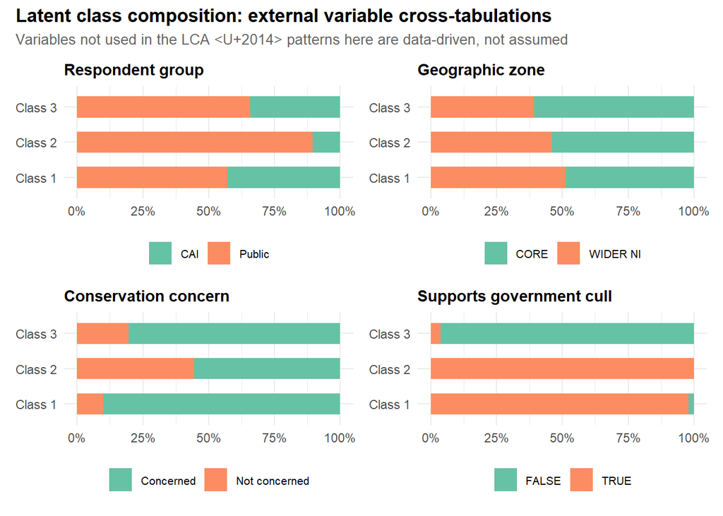

```r
# Visualise all cross-tabulations in one panel plot
plot_cross <- function(var, label, data = hare_lca) {
  data |>
    filter(!is.na(.data[[var]])) |>
    mutate(category = as.character(.data[[var]])) |>
    count(pred_class, category) |>
    group_by(pred_class) |>
    mutate(pct = n / sum(n) * 100) |>
    ggplot(aes(x = pct, y = pred_class, fill = category)) +
    geom_col(width = 0.6) +
    scale_x_continuous(labels = percent_format(scale = 1)) +
    scale_fill_brewer(palette = "Set2") +
    labs(title = label, x = NULL, y = NULL, fill = NULL) +
    theme_minimal(base_size = 11) +
    theme(legend.position = "bottom",
          legend.text      = element_text(size = 8),
          plot.title       = element_text(size = 11, face = "bold"))
}

p1 <- plot_cross("group",                        "Respondent group")
p2 <- plot_cross("zone",                         "Geographic zone")
p3 <- plot_cross("conservation_concern",         "Conservation concern")
p4 <- plot_cross("support_gov_t_cull_decision",  "Supports government cull")

(p1 + p2) / (p3 + p4) +
  plot_annotation(
    title    = "Latent class composition: external variable cross-tabulations",
    subtitle = "Variables not used in the LCA — patterns here are data-driven, not assumed",
    theme    = theme(plot.title    = element_text(size = 13, face = "bold"),
                     plot.subtitle = element_text(size = 10, colour = "grey40"))
  )
```

Bear in mind that **class labels are arbitrary**. Class 1 in one run might be Class 3 in another. The profiles are stable; the numbers are not. Always describe classes by their characteristics, not their numbers.

# Summary

- Descriptive statistics established that the CAI and Public samples have quite different activity profiles and conservation awareness levels, setting up the need for group-level comparisons.
- Chi-square tests and Fisher’s exact test revealed statistically significant group differences on most management variables, which survived Bonferroni correction.
- Phi coefficients and the association network showed that management support variables cluster tightly together, and that awareness variables are somewhat distinct, suggesting that “knowing” and “supporting” are not the same thing.
- Logistic regression identified which predictors independently predict support for a government cull, controlling for all other factors in the model.
- Thematic coding showed that shooting alone is the most common single-method prefered for lethal control, but the combination of methods differs between groups.
- LCA showed that while support for a cull is numerically strong, any management communication strategy that treats all supporters as equivalent, or all opponents as simply uninformed, is misreading the data and may be doomed to fail.

*Tutorial based on data from Caravaggi A, Montgomery WI, Reid N (2017), Biology & Environment 117B:53–63, https://doi.org/10.3318/bioe.2017.08. Dataset: https://zenodo.org/records/891251 (CC BY 4.0).*